# Agile Software Testing / QA

Кирилл Корняков,  
Динар Ахматнуров

Октябрь 2014

# Содержание

- Понятие Quality Assurance
- Традиционный подход к QA
- Agile подход к тестированию
- Пример Google
- Заключение

# Quality Assurance

- Функциональные требования
  - Наличие возможностей
  - Корректность их работы
- Нефункциональные требования
  - Производительность
  - Защищенность (security)
  - Надежность / отказоустойчивость (reliability)
  - ...

# Quality Assurance

## "Внутреннее" качество системы

- Код
  - Стиль, понятность, чистота, и т.д.
- Объектно-ориентированный дизайн
  - Возможность переиспользования, гибкость, отсутствие дублирований, и т.д.
- Архитектура
  - Модульность, расширяемость, простота

На нижнем уровне можно делать большое количество проверок автоматически.

На верхних это срабатывает только в частных вопросах.

# Виды тестов

- Модульные (unit)
  - Индивидуальные функции, методы, классы в изоляции
- Интеграционные, инфраструктурные
  - Сочетания нескольких классов, использование внешних компонент
- Системные, функциональные, приемочные (acceptance)
  - Пользовательские сценарии, end-to-end тесты

# Содержание

- Понятие Quality Assurance
- **Традиционный подход к QA**
- Agile подход к тестированию
- Пример Google
- Заключение

# Традиционный подход к QA

- Тестирование производится после разработки
  - В лучшем случае V-Model

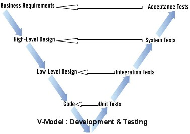

- Независимые отделы разработки и тестирования (часто разнесены)
  - Поиски оптимального соотношения числа тестировщиков к разработчикам (1:N)
- Преобладает ручное тестирование (Тех. задание, тест-планы и т.д.)
  - Автоматические тесты присутствуют, но создаются не разработчиками

# Тест Джоэла Спольски: 12 шагов к лучшему коду

## Вопрос 10. У вас есть тестеры?

> Если в вашей команде нет тестеров, по крайней мере одного на 2-3х программистов, вы либо выпускаете продукты, кишащие ошибками, либо теряете деньги.

> Работа, выполненная программистом, обойдётся вам в 100 $/час, а та же самая работа, выполненная тестером - 30 $/час.

> Экономия на тестерах - это оскорбительно ложная экономия. Я просто возмущён, почему большинство людей не замечает этого!

# Недостатки традиционного подхода

- Высокая стоимость "перетестирования"
- Медленная петля обратной связи (иногда просто ее отсутствие)
- Низкий уровень ответственности, культура конфронтации между ролями

Как результат, подобная организация практически неприменима в контексте изменяющихся требований.

# Содержание

- Понятие Quality Assurance
- Традиционный подход к QA
- **Agile подход к тестированию**
- Пример Google
- Заключение

# Гибкое тестирование

## Цели

- Production readiness culture (release in non-event)
- Уверенность при модификации/развитии системы

## Методы

- Иной взгляд на соотношение ролей разработчика и тестировщика
- Максимальная автоматизация тестирования
- Непрерывная интеграция

# Качество — ответственность разработчика

Именно у разработчика и именно в момент разработки  
есть наилучшее понимание того,  
что может сломаться и что следует тестировать.  
Поэтому он может тестировать хорошо и быстро устранять проблемы.

Примеры: Teleca, Khronos, Google

- Разработчики обеспечивают покрытие своего кода *модульными* тестами
- Покрытие тестами происходит *одновременно* с разработкой
  - Быстрая обратная связь (vs outsourced testing)
  - Фиксация "инвариантов"
  - Подготовка кода к коллективному владению
- Важен "агрессивный" стиль тестирования своего кода

# Agile Tester

- Выделенных тестеров либо совсем нет, либо их очень мало
- Находятся вместе с остальной командой
- Люди, ответственные за QA, в основном программируют (!)
  - Интеграционные и системные тесты
  - Поддержание системы непрерывной интеграции

# Автоматизация тестирования

## Полезные практики

- Огромное количество автоматических тестов
  - Покрытие близко к 100%
  - Количество "тестового" кода сравнимо с "продуктовым" (иногда 3:1)
  - Высокое качество тестового кода
- Полный прогон модульных тестов должен занимать несколько минут
  - Интеграционные и системные тесты запускаются не реже одного раза в день
- Test-Driven Development
- Перед исправлением ошибки создается тест

# Анализ качества кода

- Стиль кодирования
  - Чистый код (именование, форматирование)
  - Анализ сложности
- Статический анализ
  - Максимальный уровень предупреждений компилятора
  - Специальные инструменты
- Динамический анализ
  - Утечки памяти, гонки данных
  - Анализ производительности

# Практика непрерывной интеграции

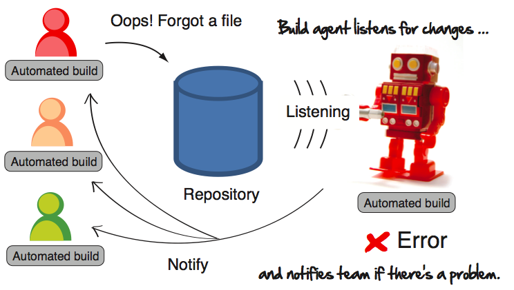

# Эволюция взглядов на интеграцию

Можно условно представить в виде следующих практик:

- **Waterfall**: разделить на компоненты, реализовать, интеграция — отдельная фаза
- **Nightly build**: интегрироваться часто, ночной билд (harthbeet of the project)
- **Continuous Integration**: интегрироваться непрерывно, тестирование каждого вливания
- **Pre-commit Testing**: интегрироваться непрерывно, но после проверки стабильности
- **Continuous Deployment**: развертываться непрерывно, но после проверки стабильности

# Автоматическое развертывание

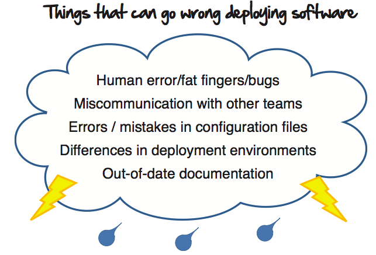

# Содержание

- Понятие Quality Assurance
- Традиционный подход к QA
- Agile подход к тестированию
- **Пример Google**
- Заключение

# Пример: Google

[figure not shown]

# Пример: Google

Подход к тестированию предложен бывшими сотрудниками Microsoft, однако он совершенно иной.

- Инженерные роли
  - Software Engineer (SE)
  - Softwate Engineer in Test (SET)
  - Test Engineer (TE)
- Основные идеи
  - Платить **одинаковую зарплату** всем инженерным ролям
  - Роли с фокусом на тестирование **должны писать код**!
- Корпоративные программы
  - "Testing on the Toilet" program (TOTT)
  - "Test Certified" Program

# Summary of Test Certified Levels

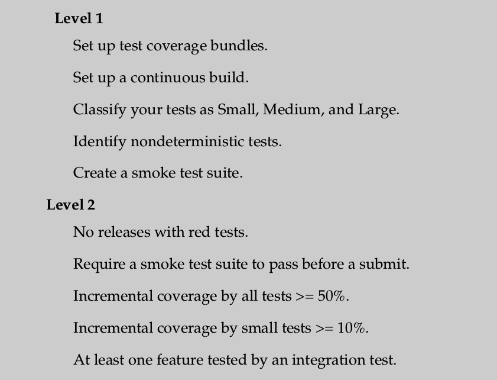

# Summary of Test Certified Levels

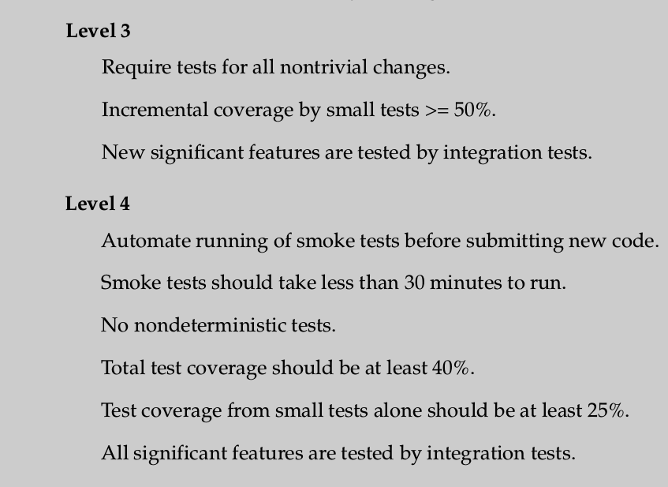

# Summary of Test Certified Levels

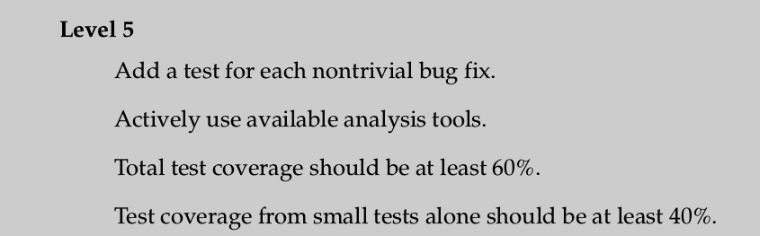

# Содержание

- Понятие Quality Assurance
- Традиционный подход к QA
- Agile подход к тестированию
- Пример Google
- **Заключение**

# Agile vs Traditional QA

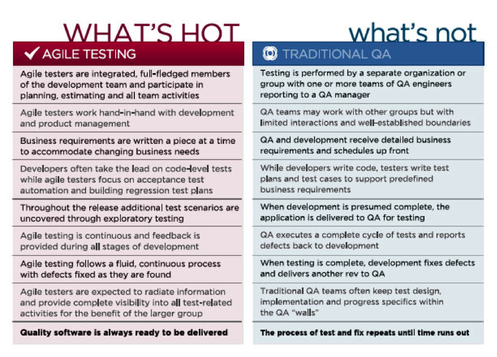

# Ключевые моменты

- Гибкий подход к тестированию позволяет развивать систему контролируемо.
- Качество — это скорее техника предотвращения ошибок, а не их детектирования.
- За качество продукта отвечает каждый разработчик.
- Написание кода и тестирование должны быть неразрывно связаны.

# Контрольные вопросы

1. Виды автоматических тестов
2. V-Model разработки ПО
3. Недостатки традиционного подхода к тестированию
4. Эволюция взглядов на интеграцию
5. Ответственность Agile-разработчика за качество
6. Ответственность Agile-тестировщика
7. Полезные практики автоматизированного тестирования
8. Виды автоматического анализа качеста кода

# Спасибо за внимание

Вопросы?